# Appendix B

Ben Weinstein

May 4, 2015

```r
library(reshape2)
library(ggplot2)

#read in data from Abundance.Rmd
load("Abundance.Rdata")
```

Sampling intensity and detection for each hummingbird species

```r
head(tab)
```

```
##   mean lower upper            Hummingbird
## 1  5.6   4.3   7.0     Booted Racket-tail
## 2  0.8   0.3   1.3   Speckled Hummingbird
## 3  2.5   1.3   3.8 Stripe-throated Hermit
## 4  5.8   4.6   7.1   Tawny-bellied Hermit
## 5  3.0   2.1   4.0    Violet-tailed Sylph
## 6  5.7   3.3   8.1 White-whiskered Hermit
```

The probability of missing a species at each daily visit is 1 - detection probability.

The probability of missing a species on sequential visits is (1- detection probability) * (1 - detection probability).

The following figure represesent the estimated number of daily surveys to capture a hummingbird event given that we know it occurs. These data can be thought of as successful draws from a negative binomial distribution.

It is easiest to interpret as the number of days until you are likely to see an interaction, so i prefer to calculate:

$1-(1-p)^n$ $p = probability of detection$ $n = days sample$

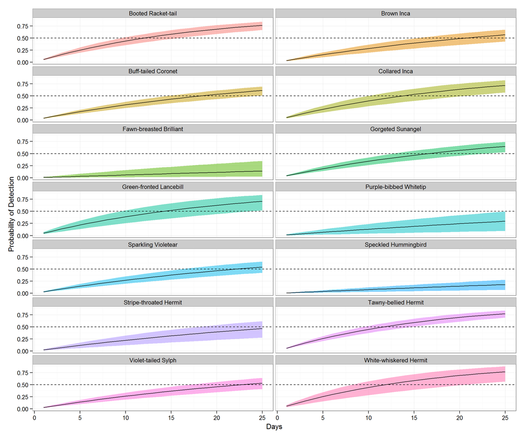

```r
dp<-function(n,p){
  1-((1-p)^n)
}

ts<-split(tab,tab$Hummingbird,drop=T)
detectd<-lapply(ts,function(x){
  meanD<-dp(n=1:25,p=x$mean/100)
  lowerD<-dp(n=1:25,p=x$lower/100)
  upperD<- dp(n=1:25,p=x$upper/100)
  data.frame(Days=1:25,mean=meanD,lower=lowerD,upper=upperD)
})

md<-melt(detectd,id.var="Days")
md<-dcast(md,...~variable)
ggplot(md,aes(x=Days,fill=L1,y=mean,ymin=lower,ymax=upper)) + geom_ribbon(alpha=.5) + geom_line() + facet_wrap(~L1,ncol=2) + geom_hline (yintercept=.5,linetype="dashed") + ylab("Probability of Detection") + scale_fill_discrete(guide="none") + theme_bw()
```

```r
ggsave("Figures/AppendixB.jpeg",height=9,width=5,dpi=300)
```

The number of days it would take to have 50% confidence you have sampled enough to capture known interactions is the x axis value where the dotted line hits the curve.